# BirdSpecies

***list of required modules***

pip install numpy==1.19.2  
pip install pandas==0.25.3  
pip install matplotlib==3.1.1  
pip install keras==2.3.1  
pip install tensorflow==1.14.0  
pip install h5py==2.10.0  
pip install jupyter==1.0.0  
pip install jupyter-client==6.1.3  
pip install jupyter-console==6.4.0  
pip install jupyter-core==4.6.3  
pip install jupyterlab-widgets==1.0.0  
pip install protobuf==3.16.0  
pip install scikit-learn==0.22.2.post1  
pip install seaborn==0.10.1  
pip install ipython==7.9.0  
pip install ipython-genutils==0.2.0  
pip install opencv-python==4.1.1.26  
pip install opencv-contrib-python==4.3.0.36  
pip install ipykernel==5.3.0  
pip install librosa==0.7.2  
pip install scipy==1.7.3  
pip install pydub==0.25.1  
pip install noisereduce==2.0.1

`pandas`: #used for data analysis and manipulation  
`numpy`: #used for scientific computing and data analysis  
`librosa`: #used for audio and music signal processing  
`StandardScaler(sklearn)`: #data preprocessing technique in machine learning that is used to standardize or scale the features of a dataset  
`train_test_split(sklearn)`: #used for splitting a dataset into two parts: a training set and a testing set. The function randomly shuffles the data and splits it into the specified proportions, which is useful for evaluating the performance of machine learning models.  
`accuracy_score`: This metric is used to evaluate the accuracy of a classification model. It is the proportion of correct predictions to the total number of predictions made by the model. The formula for accuracy_score is number of correct predictions / total number of predictions.  
`precision_score`: This metric is used to evaluate the precision of a classification model. It is the proportion of true positive predictions to the total number of positive predictions made by the model. The formula for precision_score is true positives / (true positives + false positives).  
`f1_score`: This metric is a weighted harmonic mean of the precision and recall scores. It is used to evaluate the overall performance of a classification model. The formula for f1_score is 2 * (precision * recall) / (precision + recall). `Seaborn` is a Python data visualization library based on matplotlib, which provides an interface for creating informative and attractive statistical graphics.  
`Keras` is a high-level neural networks API written in Python. It is an open-source software library that allows developers to build and train deep learning models.  
The `wave` module in Python is a built-in module that provides a way to read and write WAV (Waveform Audio File Format) files. WAV files are a common format for storing uncompressed audio data.  
The `noisereduce` module in Python is a package that provides functions for reducing noise from audio signals using spectral subtraction. It is a simple and effective method for removing stationary noise from audio signals.  
`Pydub` is a Python library for processing audio files. It provides an easy-to-use interface for loading, manipulating, and exporting audio files in various formats.

pip install anvil-uplink

```python
#load all python packages to train AlexNet by extracting MEL Spectogram features
import os
import pandas as pd
import numpy as np
import librosa
from sklearn.preprocessing import StandardScaler
#class to normalized bird fetaures
from sklearn.model_selection import train_test_split
from sklearn.metrics import accuracy_score
from keras.utils.np_utils import to_categorical
import pickle
from sklearn.metrics import confusion_matrix
from sklearn.metrics import precision_score
from sklearn.metrics import recall_score
from sklearn.metrics import f1_score
import seaborn as sns
import matplotlib.pyplot as plt
from sklearn.metrics import accuracy_score
from keras.callbacks import ModelCheckpoint
import keras
from keras import Model, layers
import wave
from scipy.io import wavfile
import noisereduce as nr #Class to remove noise
from pydub import AudioSegment
import subprocess
import os
from sklearn.metrics import roc_curve
from sklearn.metrics import roc_auc_score
from sklearn import metrics
from keras.models import Model, load_model
import warnings
warnings.simplefilter("ignore")
```

```python
import anvil.server
anvil.server.connect('server_VXDGY7ZLWHSDOMYHY4N7TABO-SKCJYEIX57GCSW4I')
```

```
Connecting to wss://anvil.works/uplink
Anvil websocket open
Connected to "Published" as SERVER
```

`FFmpeg` is a cross-platform open-source multimedia framework that is used to handle audio, video, and other multimedia files. It includes a set of tools and libraries for decoding, encoding, transcoding, filtering, and streaming audio and video.

FFmpeg can be used from the command line or as a library in your own applications. It supports a wide range of multimedia formats, including popular formats like MP3, MP4, AVI, and MOV. FFmpeg can be used for a variety of tasks, such as:

Converting between different audio and video formats Extracting audio or video from a file Adding or removing audio or video tracks from a file Splitting or merging audio or video files Applying filters to audio or video files Streaming audio or video over a network FFmpeg is a powerful tool for working with multimedia files, but it can be complex to use, especially if you are not familiar with the command line. There are also several Python libraries that provide a more user-friendly interface for using FFmpeg, such as moviepy and pydub.

The **call()** function takes a single argument, which is the command to run, as a string or a list of strings. For example, to run the ls command on a Unix-based system, you can use:

```
import subprocess
subprocess.call(["ls", "-l"])
```

**FFmpeg** is a powerful command-line tool for working with audio and video files. Here are some commonly used FFmpeg commands: Here are some common FFmpeg commands for working with audio files:

1. Convert an audio file to a different format

```
 ffmpeg -i input.mp3 output.wav
```

2. Merge multiple audio files into one:

```
ffmpeg -i "concat:input1.mp3|input2.mp3" -acodec copy output.mp3
```

3. Extract a portion of an audio file:

```
ffmpeg -i input.mp3 -ss 00:01:30 -t 00:00:30 output.mp3
```

This extracts a 30-second clip starting from the 1-minute-30-second mark.

**wavfile.read()** is a function provided by the scipy.io module in Python that reads a WAV file and returns the sampling rate and the audio data as a NumPy array.

The wavfile.read() function takes a single argument, which is the filename of the WAV file to be read. For example:

```
from scipy.io import wavfile

sampling_rate, audio_data = wavfile.read('example.wav')
```

The **sampling_rate** variable contains the sampling rate of the audio data, which is the number of samples per second. The **audio_data** variable contains the audio data as a NumPy array. Each element of the array represents the amplitude of the audio signal at a specific point in time.

In NumPy, **ndim** is an attribute of a NumPy array that returns the number of dimensions (or axes) of the array.

Here is an example of how to use ndim in NumPy:

```
import numpy as np

# create a 1D array
arr1d = np.array([1, 2, 3, 4, 5])
print(arr1d.ndim)   # output: 1

# create a 2D array
arr2d = np.array([[1, 2], [3, 4], [5, 6]])
print(arr2d.ndim)   # output: 2

# create a 3D array
arr3d = np.array([[[1, 2], [3, 4]], [[5, 6], [7, 8]]])
print(arr3d.ndim)   # output: 3
```

**nr.reduce_noise(y=data, sr=rate)** is a function call from the noisereduce module in Python, which is used for noise reduction in audio signals.

Here is a brief description of the parameters used in this function:

y: This parameter represents the audio signal to be processed. It is usually a one-dimensional NumPy array or a list of audio samples.

sr: This parameter represents the sample rate of the audio signal. It specifies the number of samples per second that were used to digitize the audio signal. For example, a sample rate of 44100 means that the audio signal was digitized using 44100 samples per second.

The reduce_noise function applies a noise reduction algorithm to the audio signal represented by the y parameter, using the sample rate specified by the sr parameter. The output of the function is a NumPy array containing the denoised audio signal.

Here's an example of how to use reduce_noise:

```
import noisereduce as nr
import soundfile as sf

# Load audio file
data, rate = sf.read("audio_file.wav")

# Reduce noise
denoised_data = nr.reduce_noise(y=data, sr=rate)

# Save denoised audio file
sf.write("denoised_audio_file.wav", denoised_data, rate)
```

In this example, reduce_noise is used to reduce the noise in an audio file called "audio_file.wav". The denoised audio signal is then saved to a new file called "denoised_audio_file.wav".

```python
path = "audio"
if os.path.exists("NoiseCleanAudio") == False: #function to clean noise and silence from audio
    for root, dirs, directory in os.walk(path):#loop all files
        for j in range(len(directory)):
            name = os.path.basename(root)
            subprocess.call(['ffmpeg', '-i', "audio/"+name+"/"+directory[j], 'test.wav'])#convert mp3 to wav file
            rate, data = wavfile.read("test.wav")
            if data.ndim == 1:
                reduced_noise = nr.reduce_noise(y=data, sr=rate) #now remove noise from the audio
                wavfile.write("NoiseCleanAudio/"+name+"/"+directory[j], rate, reduced_noise)#save noised remove audio file
            if os.path.exists("test.wav") == True:
                os.remove("test.wav")
print()
print("All noise cleaned audio file processed and saved inside NoiseCleanAudio")
print()
```

```
All noise cleaned audio file processed and saved inside NoiseCleanAudio
```

The os.walk() function in Python is used to traverse a directory tree. It is an iterator which yields a 3-tuple containing the directory path, the directory names, and the file names. The os.walk() function is useful for iterating through all the files and subdirectories of a directory tree. It is important to note that the os.walk() function does not traverse symbolic links.

subprocess.call(['ffmpeg', '-i', audio_file, 'test1.wav']) is a call to the ffmpeg command-line tool for audio/video conversion. The command takes three arguments: the name of the ffmpeg executable, the '-i' switch (used to specify an input file), and the path of the audio file you want to convert. After calling this subprocess, the audio file will be converted from its original format (specified by the file extension) to the format specified by the 'test1.wav' argument.

The following code provided is written in Python and is used to get the unique identifier of a species of bird from its name. The function `getID()` takes the name of the species as an argument and uses a `for` loop to search through a list of `labels` for a match. If a match is found, the index of the match is returned.

The list of labels is initialized as an empty list and then populated with a `for` loop that searches through the files in the "NoiseCleanAudio" directory using the `os.walk()` function. For each file, the directory name is extracted as the name of the bird species, and if it is not already in the list, it is added. Finally, a list of birds species found in the dataset is printed out.

```python
def getID(name): #function to get ID of the bird as label from species names
    index = 0
    for i in range(len(labels)):
        if labels[i] == name:
            index = i
            break
    return index
labels = []
for root, dirs, directory in os.walk("NoiseCleanAudio"):#now loop all files and get labels and then display all birds names
    for j in range(len(directory)):
        name = os.path.basename(root)
        if name not in labels:
            labels.append(name)
print("Bird Species found in dataset")
print()
for i in range(len(labels)):
    print(labels[i])
```

```
Bird Species found in dataset

Buff-throated Woodcreeper
Lesser Woodcreeper
Olivaceous Woodcreeper
Yellow-olive Flatbill
```

```python
import subprocess
def plotSignal(audio_file, name):#function to plot signal graph
    subprocess.call(['ffmpeg', '-i', audio_file, 'test1.wav'])
    spf = wave.open("test1.wav", "r")
    signal = spf.readframes(-1)
    signal = np.fromstring(signal, "Int16")
    plt.figure(1)
    plt.title(name)
    plt.plot(signal)
    plt.show()
```

The above function `plotSignal()` which takes in the audio file and a name as parameters. The code then uses `ffmpeg` to convert the audio file into a wav file and stores it into the `test1.wav` file. Afterwards, the code uses `wave` to open the `test1.wav` file and reads the frames from it. The frames are then converted from a string format into an array of integer values. Finally, the code creates a figure, adds a title to it, plots the signal and displays it. The output is a graph of the signal which is useful for analyzing audio data.

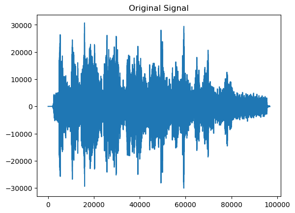

```python
if os.path.exists("test1.wav"):
    os.remove("test1.wav")
plotSignal("audio/Buff-throated-Woodcreeper/5632.mp3", "Original Signal") #now plot signal graph with noise
```

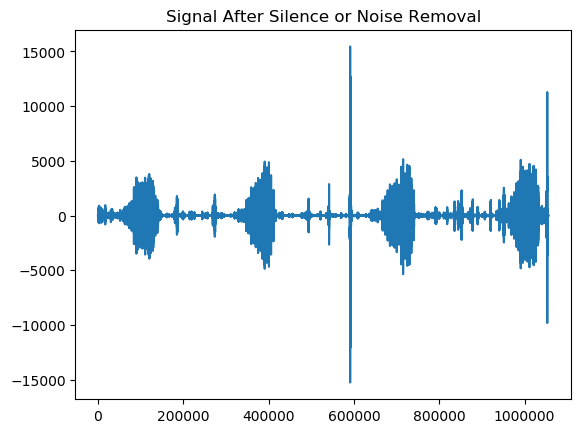

```python
if os.path.exists("test1.wav"):#now signal graph without noise
    os.remove("test1.wav")
plotSignal("NoiseCleanAudio/Buff-throated Woodcreeper/4760.mp3", "Signal After Silence or Noise Removal")
```

```
Dataset loaded
```

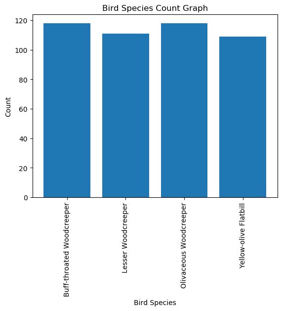

```python
if os.path.exists('model/X.txt.npy'):
    X = np.load('model/X.txt.npy')
    Y = np.load('model/Y.txt.npy')
    #print(X)
else:
    X = []
    Y = []
    for root, dirs, directory in os.walk("NoiseCleanAudio"):#loop all audio files from the dataset
        for j in range(len(directory)):
            name = os.path.basename(root)
            audio, sr = librosa.load(path=Dataset+'/'+name+"/"+directory[j], sr=None)#now read audio wav file frames
            audio = librosa.effects.time_stretch(y=audio, rate=len(audio)/sr) #extract sample rate from the audio
            # Get spectrogram features and get the label from the filename
            mels = librosa.feature.melspectrogram(y=audio, sr=sr, n_fft=2048, hop_length=512)#now extract mel features
            mels_db = librosa.power_to_db(S=mels, ref=1.0)
            if mels_db.shape[1] == 87:
                X.append(mels_db.ravel()) #add spectrogram audio features to array
                label = getID(name)#get bird species names as label
                Y.append(label)
    X = np.asarray(X)
    Y = np.asarray(Y)
    #print(X)
    np.save('model/X.txt',X)
    np.save('model/Y.txt',Y)
print()
print("Dataset loaded")
unique, count = np.unique(Y, return_counts = True)
unique = ['Buff-throated Woodcreeper', 'Lesser Woodcreeper', 'Olivaceous Woodcreeper', 'Yellow-olive Flatbill']
height = count
bars = unique
y_pos = np.arange(len(bars))
plt.bar(y_pos, height)
plt.xticks(y_pos, bars)
plt.title("Bird Species Count Graph")
plt.xlabel("Bird Species")
plt.ylabel("Count")
plt.xticks(rotation=90)
plt.show()
```

In the below code cell,  
StandardScaler() is a preprocessing method in machine learning that is used to transform the data into a standard scale. It is used to transform the dataset values into a normalized form that is more suitable for further processing.

Using the scaler, the features are transformed so that each feature has a mean value of 0 and a standard deviation of 1. This helps the model to have better predictability as it reduces the effect of outliers and makes the data more consistent.

After the dataset is scaled, it should be shuffled in order to obtain random observations from the dataset. This is accomplished by using the np.random.shuffle() function.

Finally, the dataset is split into training and testing sets, with 80% for training and 20% for testing and validation. The X_train and y_train variables contain the training data, while the X_test and y_test variables contain the test data. This split allows for more accurate model results due to better validation of the model on unseen data.

```python
#dataset preprocessing such as normalization, dataset shuffling and train and test split
scaler = StandardScaler()
X = scaler.fit_transform(X)#normalizing or scaling dataset values
indices = np.arange(X.shape[0])
np.random.shuffle(indices)#shuffling the dataset
X = X[indices]
Y = Y[indices]
Y = to_categorical(Y)
X = np.reshape(X, (X.shape[0], 128, 87, 1))
X_train, X_test, y_train, y_test = train_test_split(X, Y, test_size=0.2) #split dataset into train and test
print()
print("Dataset Train & Test Split where 80% records for training and 20% for testing and validation")
print("80% training records : "+str(X_train.shape[0]))
print("20% testing records  : "+str(X_test.shape[0]))
```

```
Dataset Train & Test Split where 80% records for training and 20% for testing and validation
80% training records : 364
20% testing records  : 92
```

```python
#defining global features to store accuracy and other values
accuracy = []
precision = []
recall = []
fscore = []
```

The code cell below is a method used to calculate the accuracy score, precision score, recall score, and F-score of a given algorithm. It takes as parameters the algorithm, the actual labels (y_test) and the predicted labels (predict). The accuracy score is calculated based on the actual and predicted labels, and is expressed as a percentage. Similarly, the precision score, recall score and F-score are also calculated, and expressed as a percentage.

The code then prints out the various scores for the given algorithm. This is followed by the creation of a confusion matrix, which is a visual representation of the algorithm's performance. The confusion matrix displays the true class vs the predicted class, and is plotted using a heat map.

Overall, this code snippet is used to calculate and visualize the performance of a given algorithm.

```python
#function to calculate all metrics
def calculateMetrics(algorithm, y_test, predict):
    a = accuracy_score(y_test,predict)*100
    p = precision_score(y_test, predict,average='macro') * 100
    r = recall_score(y_test, predict,average='macro') * 100
    f = f1_score(y_test, predict,average='macro') * 100
    accuracy.append(a)
    precision.append(p)
    recall.append(r)
    fscore.append(f)
    print(algorithm+" Accuracy  :  "+str(a))
    print(algorithm+" Precision : "+str(p))
    print(algorithm+" Recall    : "+str(r))
    print(algorithm+" FScore    : "+str(f))
    conf_matrix = confusion_matrix(y_test, predict)
    labels = unique
    plt.figure(figsize =(6, 5))
    ax = sns.heatmap(conf_matrix, xticklabels = labels, yticklabels = labels, annot = True, cmap="viridis" ,fmt ="g");
    ax.set_ylim([0,len(labels)])
    plt.title(algorithm+" Confusion matrix")
    plt.ylabel('True class')
    plt.xlabel('Predicted class')
    plt.show()
```

1. `Keras.layers.Conv2D` is a convolutional layer in Keras, which is a deep learning library written in Python. This layer is used to create a Convolutional Neural Network (CNN). The filter parameter determines the number of kernels or filters used in the convolutional layer, the kernel size determines the size of the convolutional filter, the strides parameter determines the step size of the convolution, and the activation parameter is used to apply a nonlinear activation function. The input_shape parameter is used to specify the shape of the input data, and in this case, it is the shape of the training data. This layer is used to detect features in an image by using the convolution operation. By using multiple convolutional layers and applying a nonlinear activation function, deep neural networks can be created to accurately identify features in an image.
2. Keras' BatchNormalization() layer is used to normalize the input layer by re-centering and rescaling it. This ensures the inputs to the layer have a mean of 0 and standard deviation of 1. This helps speed up and improve the training of deep neural networks by reducing the internal covariate shift. The BatchNormalization() layer also applies a learnable bias and scaling after normalization, allowing for greater flexibility in the model.
3. Keras.layers.MaxPool2D is a type of pooling layer used in convolutional neural networks. It reduces the spatial size of the input by taking the maximum value from each pool size (usually 2x2, but in this case it is 1x1). The strides parameter specifies the size of the step the filter moves across the input layer. In this example, the strides are set to (2,2), meaning that the filter will take 2 values at a time from the input layer and store the maximum value. This pooling layer is beneficial because it reduces the size of the input, helping to reduce the number of parameters and computational cost in the neural network.
4. `Keras.layers.Flatten()` is a layer type used in Keras, a deep learning framework. This layer is used to flatten the input, which means that it takes the input and transforms it into a one-dimensional array. This layer is mainly used as the input layer for deep learning models, as it helps to reformat the data for the model. It is important to note that the output of this layer does not have any parameters, which means that it does not have any weights or biases associated with it.
5. `Keras.layers.Dense(4096, activation='relu')` is a layer in a neural network model. This layer is a densely connected neural layer with 4096 neurons and the activation function used is ReLU. The ReLU activation function is a widely used non-linear activation function which has the advantage of being computationally efficient and providing a regularization effect due to its sparse nature. By using this layer, you are able to expand the model’s ability to detect complex patterns in the data to increase accuracy and performance.
6. `Keras.layers.Dropout(0.4)` is a Dropout layer in Keras, a deep learning library. It is used as a regularizer to prevent overfitting of the model by randomly dropping units (neurons) from the network at each iteration. It takes a single float parameter, which is the fraction of units to drop (0.4 in this example). This helps to prevent the model from becoming too dependent on any particular input or feature by randomly dropping them during training, thus making the model more general.
7. The `softmax` function is a type of activation function which outputs a vector of probabilities summing to 1, making it useful for classification tasks.
8. `load_model("model/model_weights.hdf5")` is a Keras API that loads the pre-trained weights of a model from a HDF5 file. This file can be generated from a trained model and can be used to construct a new model with the same architecture and weights. It is an efficient way to save and load a trained model, and helps avoid the need to rebuild the model from scratch every time it needs to be used.

```python
#now train Alexnet with CNN 5 layers and added extra 3 layers with number of neurons as 9,9 and 7,7 and 6,6
alexnet_model = keras.models.Sequential([
    keras.layers.Conv2D(filters=96, kernel_size=(11,11), strides=(4,4), activation='relu', input_shape=(X_train.shape[1],X_train.shape[2],X_train.shape[3])),
    keras.layers.BatchNormalization(),
    keras.layers.MaxPool2D(pool_size=(1,1), strides=(2,2)),
    keras.layers.Conv2D(filters=256, kernel_size=(9,9), strides=(1,1), activation='relu', padding="same"),
    keras.layers.BatchNormalization(),
    keras.layers.MaxPool2D(pool_size=(1,1), strides=(2,2)),
    keras.layers.Conv2D(filters=256, kernel_size=(7,7), strides=(1,1), activation='relu', padding="same"),
    keras.layers.BatchNormalization(),
    keras.layers.MaxPool2D(pool_size=(1,1), strides=(2,2)),
    keras.layers.Conv2D(filters=256, kernel_size=(6,6), strides=(1,1), activation='relu', padding="same"),
    keras.layers.BatchNormalization(),
    keras.layers.MaxPool2D(pool_size=(1,1), strides=(2,2)),
    keras.layers.Conv2D(filters=256, kernel_size=(5,5), strides=(1,1), activation='relu', padding="same"),
    keras.layers.BatchNormalization(),
    keras.layers.MaxPool2D(pool_size=(1,1), strides=(2,2)),
    keras.layers.Conv2D(filters=384, kernel_size=(3,3), strides=(1,1), activation='relu', padding="same"),
    keras.layers.BatchNormalization(),
    keras.layers.Conv2D(filters=384, kernel_size=(3,3), strides=(1,1), activation='relu', padding="same"),
    keras.layers.BatchNormalization(),
    keras.layers.Conv2D(filters=256, kernel_size=(3,3), strides=(2,2), activation='relu', padding="same"),
    keras.layers.BatchNormalization(),
    keras.layers.MaxPool2D(pool_size=(1,1), strides=(2,2)),
    keras.layers.Flatten(),
    keras.layers.Dense(4096, activation='relu'),
    keras.layers.Dropout(0.4),
    keras.layers.Dense(4096, activation='relu'),
    keras.layers.Dropout(0.4),
    keras.layers.Dense(y_train.shape[1], activation='softmax')
])
alexnet_model.compile(loss='categorical_crossentropy', optimizer="adam", metrics=['accuracy'])#compiling the model
print(alexnet_model.summary())
#training and loading the model
if os.path.exists("model/model_weights.hdf5") == False:
    model_check_point = ModelCheckpoint(filepath='model/model_weights.hdf5', verbose = 1, save_best_only = True)
    hist = alexnet_model.fit(X_train, y_train, batch_size = 8, epochs = 20, validation_data=(X_test, y_test), callbacks=[model_check_point], verbose=1)
    f = open('model/history.pckl', 'wb')
    pickle.dump(hist.history, f)
    f.close()
else:
    alexnet_model = load_model("model/model_weights.hdf5")
```

```
WARNING:tensorflow:From C:\Users\DELL\AppData\Local\Programs\Python\Python37\lib\site-packages\keras\backend\tensorflow_backend.py:4070: The name tf.nn.max_pool is deprecated. Please use tf.nn.max_pool2d instead.

Model: "sequential_1"
_________________________________________________________________
Layer (type)                 Output Shape              Param #
=================================================================
conv2d_1 (Conv2D)            (None, 30, 20, 96)        11712
_________________________________________________________________
batch_normalization_1 (Batch (None, 30, 20, 96)        384
_________________________________________________________________
max_pooling2d_1 (MaxPooling2 (None, 15, 10, 96)        0
_________________________________________________________________
conv2d_2 (Conv2D)            (None, 15, 10, 256)       1990912
_________________________________________________________________
batch_normalization_2 (Batch (None, 15, 10, 256)       1024
_________________________________________________________________
max_pooling2d_2 (MaxPooling2 (None, 8, 5, 256)         0
_________________________________________________________________
conv2d_3 (Conv2D)            (None, 8, 5, 256)         3211520
_________________________________________________________________
batch_normalization_3 (Batch (None, 8, 5, 256)         1024
_________________________________________________________________
max_pooling2d_3 (MaxPooling2 (None, 4, 3, 256)         0
_________________________________________________________________
conv2d_4 (Conv2D)            (None, 4, 3, 256)         2359552
_________________________________________________________________
batch_normalization_4 (Batch (None, 4, 3, 256)         1024
_________________________________________________________________
max_pooling2d_4 (MaxPooling2 (None, 2, 2, 256)         0
_________________________________________________________________
conv2d_5 (Conv2D)            (None, 2, 2, 256)         1638656
_________________________________________________________________
batch_normalization_5 (Batch (None, 2, 2, 256)         1024
_________________________________________________________________
max_pooling2d_5 (MaxPooling2 (None, 1, 1, 256)         0
_________________________________________________________________
conv2d_6 (Conv2D)            (None, 1, 1, 384)         885120
_________________________________________________________________
batch_normalization_6 (Batch (None, 1, 1, 384)         1536
_________________________________________________________________
```

[output cut: 13 more lines]

```
_________________________________________________________________
dropout_1 (Dropout)          (None, 4096)              0
_________________________________________________________________
dense_2 (Dense)              (None, 4096)              16781312
_________________________________________________________________
dropout_2 (Dropout)          (None, 4096)              0
_________________________________________________________________
dense_3 (Dense)              (None, 4)                 16388
=================================================================
Total params: 30,168,900
Trainable params: 30,164,612
Non-trainable params: 4,288
_________________________________________________________________
None
WARNING:tensorflow:From C:\Users\DELL\AppData\Local\Programs\Python\Python37\lib\site-packages\keras\backend\tensorflow_backend.py:422: The name tf.global_variables is deprecated. Please use tf.compat.v1.global_variables instead.
```

The `sns.heatmap()` function in Python's seaborn library is used to create a heatmap visualization. The `conf_matrix` parameter is used to pass in the confusion matrix, which is a table containing the true labels and predicted labels of a given dataset. The `xticklabels` parameter is used to set the labels for the x-axis, and the `yticklabels` parameter is used to set the labels for the y-axis. The `annot` parameter is used to indicate whether or not the numbers should be annotated inside the heatmap. The `cmap` parameter is used to set the color scheme for the heatmap, and the `fmt` parameter is used to define the format of the annotation numbers.  
By using the `sns.heatmap()` function, you can quickly and easily create an informative visualization of the confusion matrix, allowing you to better understand the results of your predictive model.

`calculateMetrics` is defined in 14th cell

```
AlexNet CNN Model Accuracy  :  98.91304347826086
AlexNet CNN Model Precision : 98.80952380952381
AlexNet CNN Model Recall    : 98.95833333333334
AlexNet CNN Model FScore    : 98.858329008822
```

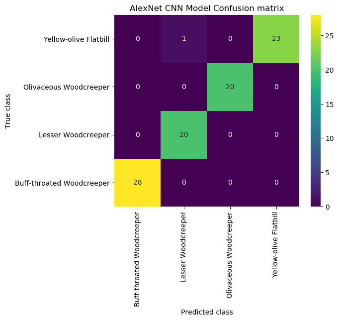

```python
#perform prediction on test data and calculate metrics like accuracy, precision etc
predict = alexnet_model.predict(X_test)
predict = np.argmax(predict, axis=1)
y_test1 = np.argmax(y_test, axis=1)
calculateMetrics("AlexNet CNN Model", y_test1, predict)
```

The given code creates a DataFrame object from the Python's pandas library. The columns argument is an array of strings which represent the labels of the columns of the DataFrame. The values argument is an array of values which correspond to the columns of the DataFrame. The algorithm_names argument is a list of algorithm names. For each algorithm name, precision, recall, FScore and accuracy values are extracted from the corresponding arrays and then appended to the values argument. Finally, the DataFrame object is created by passing the columns and values arguments to the pd.DataFrame() function. The result is the DataFrame object, which can be printed by calling the print() function on the DataFrame object. This DataFrame can then be used for further analysis.

```python
#Performance of Alexnet model
columns = ["Algorithm Name","Precison","Recall","FScore","Accuracy"]
values = []
algorithm_names = ["AlexNet CNN"]
for i in range(len(algorithm_names)):
    values.append([algorithm_names[i],precision[i],recall[i],fscore[i],accuracy[i]])

temp = pd.DataFrame(values,columns=columns)
temp
```

|  | Algorithm Name | Precison | Recall | FScore | Accuracy |
| --- | --- | --- | --- | --- | --- |
| 0 | AlexNet CNN | 98.809524 | 98.958333 | 98.858329 | 98.913043 |

```python
def plotImage(name, title):#plot bird species image after prediction
    import cv2
    img = cv2.imread(name)
    img = cv2.resize(img, (600,400))
    cv2.putText(img, title, (10, 25),  cv2.FONT_HERSHEY_SIMPLEX,0.8, (255, 0, 0), 2)
    plt.imshow(img)
    #plt.title('Brain Tumor Sample Processed Image')
    plt.axis('off')
    plt.show()
```

This code is used to predict the species of a bird based on an audio file. The code starts by loading the audio file and extracting the sample rate. Then the audio is processed to calculate features, such as a Mel Spectrogram, which is used to create a melspectrogram with a Fast Fourier Transform (FFT) size of 2048, and a hop length of 512. The melspectrogram is then converted to dB for normalization, and the features are converted to two-dimensional features for normalization. The normalized features are then fed as input to an AlexNet model, which is used to perform prediction on the audio file. Finally, the predicted label is identified and the corresponding image of the bird species is plotted.

```python
#now perform prediction on test data
#@anvil.server.callable
def predictSpecies(audio_file):
    audio, sr = librosa.load(path=audio_file, sr=None)#now read audio wav file
    audio = librosa.effects.time_stretch(y=audio, rate=len(audio)/sr) #extract sample rate from the audio
    # Calculate features and get the label from the filename
    mels = librosa.feature.melspectrogram(y=audio, sr=sr, n_fft=2048, hop_length=512)#now extract sepctogram features
    mels_db = librosa.power_to_db(S=mels, ref=1.0)
    test = []
    test.append(mels_db.ravel()) #now convert multi dimension fetaures to 2 dimension fetaures for normalization
    test = np.asarray(test)
    test = scaler.transform(test) #normalizing test audio fetaurfes
    test = np.reshape(test, (test.shape[0], 128, 87, 1))
    predict = alexnet_model.predict(test) #perform prediction on test bird audio file
    predict = np.argmax(predict, axis=1)
    print("Given Bird Species Identified as : "+labels[predict[0]])
    plotImage("images/"+str(predict[0])+".jpg", labels[predict[0]]) #plot image of predicted bird audio file
```

```python
!pip install opencv-python==4.1.1.26
!pip install opencv-contrib-python==4.3.0.36
```

```
Given Bird Species Identified as : Buff-throated Woodcreeper
```

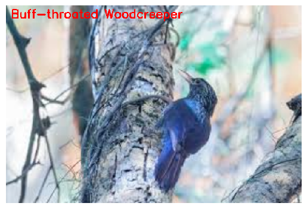

```python
predictSpecies("testAudio/22.mp3")#now identify species from audio file
```

```
Given Bird Species Identified as : Lesser Woodcreeper
```

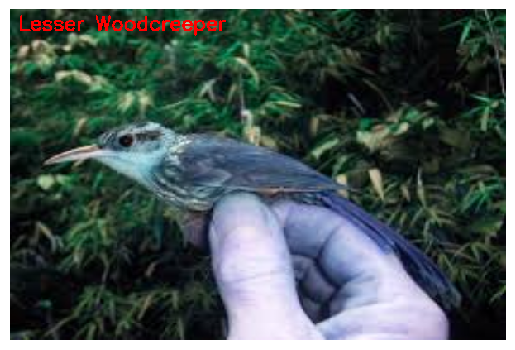

```python
predictSpecies("testAudio/0.mp3")#now identify species from audio file
```

```
Given Bird Species Identified as : Yellow-olive Flatbill
```

[figure not shown]

```python
predictSpecies("testAudio/60.mp3")#now identify species from audio file
```

```
Given Bird Species Identified as : Olivaceous Woodcreeper
```

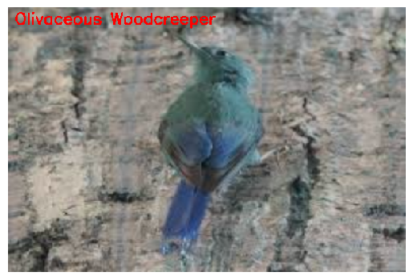

```python
predictSpecies("testAudio/11.mp3")#now identify species from audio file
```

```python
print('server is up and running')
print('visit https://qawtrans.anvil.app')
anvil.server.wait_forever()
```

```
server is up and running
visit https://qawtrans.anvil.app
```